# Practical Machine Learning Project

Brian Saunders

Sunday, January 25, 2015

## Synopsis

```r
library(caret)
library(randomForest)
WLEcases <- read.csv("pml-testing.csv")
WLEdata <- read.csv("pml-training.csv")
```

The variables related to row number and time stamps should not be a factor in this analysis. In addition, the rows where the window is new and additional variables are generated represent a small number of cases, and in none of the test cases are those variables present. Consequently, I will drop them.

```r
droppat <- "^kurtosis_|^skewness_|^max_|^min_|^amplitude_|^var_|^avg_|^stddev_"
testdrop <- grepl(droppat,names(WLEcases))
traindrop <- grepl(droppat,names(WLEdata))
testdrop[1:7] = TRUE
traindrop[1:7] = TRUE
WLEcases <- WLEcases[,!testdrop]
WLEdata <- WLEdata[,!traindrop]

set.seed(92122)
RFtrain <- createDataPartition(y=WLEdata$classe,p=0.75,list=FALSE)
WLEtrain <- WLEdata[RFtrain,]
WLEtest <- WLEdata[-RFtrain,]
```

First I’ll try fitting all the variables.

```r
WLEfullmod <- randomForest(classe ~ .,data=WLEtrain)
print(WLEfullmod)
```

```
##
## Call:
##  randomForest(formula = classe ~ ., data = WLEtrain)
##                Type of random forest: classification
##                      Number of trees: 500
## No. of variables tried at each split: 7
##
##         OOB estimate of  error rate: 0.46%
## Confusion matrix:
##      A    B    C    D    E class.error
## A 4182    2    1    0    0   0.0007168
## B    9 2834    5    0    0   0.0049157
## C    0   12 2552    3    0   0.0058434
## D    0    0   28 2382    2   0.0124378
## E    0    0    4    2 2700   0.0022173
```

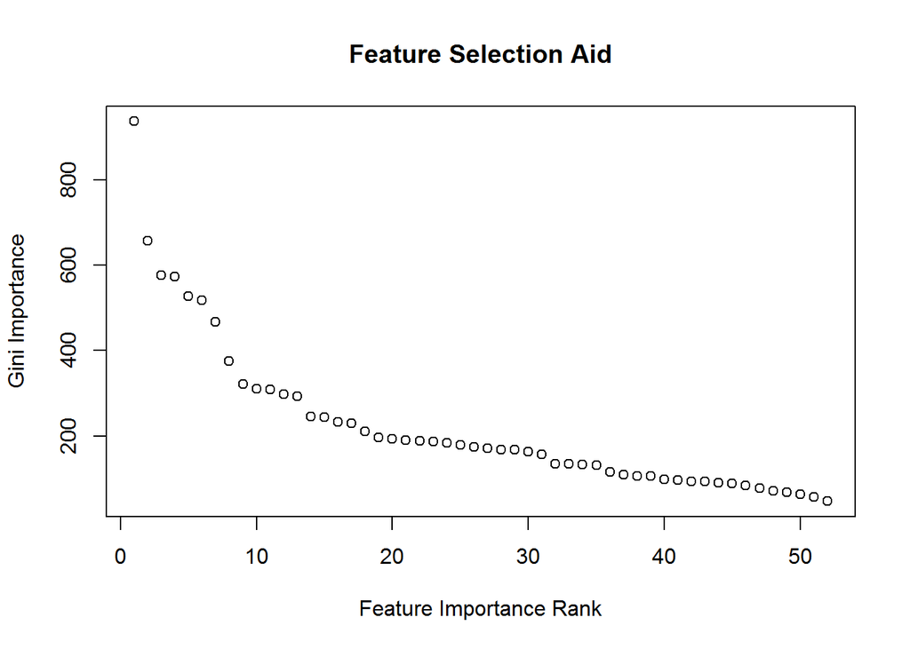

```r
WLEfimp <- importance(WLEfullmod,type=2)
plot(WLEfimp[order(-WLEfimp)],xlab="Feature Importance Rank",ylab="Gini Importance",
     main="Feature Selection Aid")
```

The plot of the feature importance shows a steadily decreaing value of the Gini Importance, but no obvious place where we could cut off the number of features we use. I will use cross-validation with the random forest model data.

```r
WLEfcv <- rfcv(WLEtrain[,-53],WLEtrain$classe)
print(WLEfcv$error.cv)
```

```
##       52       26       13        6        3        1
## 0.006183 0.007678 0.010803 0.043688 0.109798 0.602120
```

From the results of the cross-validation, we see a steadily decreasing error rate, even when all variables are used. This suggests that using all variables will probably not result in overfitting. I will still build a model with 1/2 of the variables (26) in order to compare.

```r
WLEt26form <- as.formula(paste("classe~",paste(names(WLEtrain)[order(-WLEfimp)][1:26],collapse="+")))
WLEt26mod <- randomForest(WLEt26form,data=WLEtrain)
print(WLEt26mod)
```

```
##
## Call:
##  randomForest(formula = WLEt26form, data = WLEtrain)
##                Type of random forest: classification
##                      Number of trees: 500
## No. of variables tried at each split: 5
##
##         OOB estimate of  error rate: 0.63%
## Confusion matrix:
##      A    B    C    D    E class.error
## A 4178    5    2    0    0    0.001673
## B   16 2815   17    0    0    0.011587
## C    0   15 2548    4    0    0.007402
## D    0    0   23 2388    1    0.009950
## E    0    0    5    4 2697    0.003326
```

```r
WLEfpred <- predict(WLEfullmod,WLEtest)
table(WLEfpred,WLEtest$classe)
```

```
##
## WLEfpred    A    B    C    D    E
##        A 1395    8    0    0    0
##        B    0  940    4    0    0
##        C    0    1  851    5    0
##        D    0    0    0  797    1
##        E    0    0    0    2  900
```

```r
WLEt26pred <- predict(WLEt26mod,WLEtest)
table(WLEt26pred,WLEtest$classe)
```

```
##
## WLEt26pred    A    B    C    D    E
##          A 1391    7    0    0    0
##          B    1  932    3    0    0
##          C    2   10  851    3    0
##          D    0    0    1  799    1
##          E    1    0    0    2  900
```

A comparison of the confusion tables for these cases indicates that even though the 26-variable model only produces a slighly larger error (0.63% versus 0.46%), I am sticking with the full model for prediction.

```r
casepred <- predict(WLEfullmod,WLEcases)
for (i in 1:length(casepred)) {
filename = paste0("problem_id_",i,".txt")
write.table(casepred[i],file=filename,quote=FALSE,row.names=FALSE,col.names=FALSE)
}
```